# COMP_HW

Amanda Crosby

2023-10-07

```r
library(dplyr)
library(psych)
library(car)
library(tidyverse)
library(readxl)
library(effectsize)
library(gridExtra)
source("610710_functions.R")
knitr::opts_chunk$set(echo = TRUE, message = FALSE, warning = FALSE)
```

# Conceptual Questions

## 1.

### a.

#### I do not think Shourya has a reliable measure of physical health. He is

#### using self-report questionnaires to measure physical health. It is not a

#### standardized or objectional measure of health such as physical assessments.

#### He also only has a sample of 5, and is not taking into account physical

#### health data prior to watching the vidoes. It is unlikely that a

#### participants physical health would change after watching a Youtube video.

### b.

#### The first type of validity is external validity; the extent to which we can

#### generalize the findings from our study to the population. In Shourya’s

#### study, external validity is not satisfactory. His sample is small and

#### homogenous (5 college students). Because of this, the findings may not

#### represent the larger population. Additionally, Shourya manipulated

#### depression by showing participants either a comedy or tragic video. This

#### may not generalize to individualls with diagnosed clinical depression. The

#### second type of validity is conclusion validity; the extent to which the

#### study allows us to detect an effect if an effect exists in the population.

#### Shourya’s study is not satisfactory in conclusion validity due to the lack

#### of random assignment. The participants self-selected themselves into

#### groups, so it might be an uneven distribution. He also failed to control

#### confounding variables that may have an effect on physical health. The third

#### type of validity is internal validity; the extent to which the study allows

#### us to draw causal conclusions about the effect of the predictor variable on

#### the outcome variable. Shourya’s study is not satisfactory in internal

#### validity due to lack of random assignment, the test-retest method, and the

#### lack of explaining confounding variables. In a test-retest study,

#### participants scores tend to be closer to the mean the second time around.

#### The fourth type of validity is construct validity; the extent to which an

#### indicator measures what it was intended to measure. Shourya’s study is not

#### satisfactory in construct validity due to the control groups. Watching a

#### sad or happy video may induce an emotional reaction, but does not directly

#### represent depression.

### c.

#### One change Shourya could make in his study is to icnrease the sample size

#### and use random assignment. This change would increase external validity

#### because having a larger sample makes it more likely you will be able to

#### generalize your findings to the larger population. This change would also

#### increase conclusion validity because any differences in outcomes between

#### groups can be more confidently attributed to the independent variable,

#### rather than alternative explanations. Another change Shourya could make in

#### his study is to have both self-report questionnaires and physical

#### assessments to measure physical health. This change would make the measure

#### of physical health more reliable, therefore increasing construct validity.

## 2.

### a.

#### Erin is 22 years old. z=(score - mean) / (standard deviation) ->

#### 1 = (score - 20.5)/1.5 -> 1.5 = score - 20.5 -> score = 22.

### b.

#### The sum of squared errors is the standard error in relation to a sampling

#### distribution.

### c.

#### A z-distribution is used when you know the population standard deviation.

#### A t-distribution is used when you only know the sample standard deviation.

## 3.

### a.

#### Two alternatice ways to aggregate separate error values into a summary

#### measure of total error are sum or errors (SE) and sum of absoulte errors

#### (SAE).

### b.

#### Sum of absolute error (SAE) would be minimized if we used the sample median

#### instead of the sample mean as our parameter estimate for b0.

### c.

#### Mean squared error (MSE) is the remaining error per remaining potential

#### parameter. In the basic/mean-only model the MSE is also known as the

#### variance.

## 4.

### d.

#### The numerator of the F statistic represents the average SSE reduction from

#### the compact to the augmented model, per each parameter added to the

#### augmented model that was not in the compact model.The denominator of the F-

#### statistic represents the variance unexplained by the augmented model.

## 5.

# Data Analysis

## 6.

### a.

#### The independent variables are cognitive ability and supportive parenting.

#### The dependent variables are imagination and agreeableness.

### b.

```r
d_raw <- read.csv("Comp_1_data.csv")
```

### c.

```r
d <- d_raw %>% janitor::clean_names(case = "snake")
```

### d.

```r
summary(d)
```

```
##       aid                scid            ah_pvt         sup_parent
##  Min.   :12578037   Min.   :  1.00   Min.   : 51.00   Min.   :1.00
##  1st Qu.:92506891   1st Qu.: 41.00   1st Qu.: 90.00   1st Qu.:1.00
##  Median :94578407   Median : 71.00   Median :100.00   Median :1.00
##  Mean   :93703600   Mean   : 98.78   Mean   : 99.75   Mean   :1.48
##  3rd Qu.:97572043   3rd Qu.:117.00   3rd Qu.:111.00   3rd Qu.:2.00
##  Max.   :99886996   Max.   :999.00   Max.   :146.00   Max.   :2.00
##                                      NA's   :157      NA's   :193
##   parent_div            agr_1           agr_2           agr_3
##  Length:3093        Min.   :1.000   Min.   :1.000   Min.   :1.000
##  Class :character   1st Qu.:4.000   1st Qu.:3.000   1st Qu.:2.000
##  Mode  :character   Median :4.000   Median :4.000   Median :2.000
##                     Mean   :4.161   Mean   :3.639   Mean   :2.196
##                     3rd Qu.:5.000   3rd Qu.:4.000   3rd Qu.:2.000
##                     Max.   :5.000   Max.   :5.000   Max.   :5.000
##                     NA's   :752     NA's   :752     NA's   :755
##      agr_4           ima_1           ima_2           ima_3
##  Min.   :1.000   Min.   :1.000   Min.   :1.000   Min.   :1.000
##  1st Qu.:2.000   1st Qu.:3.000   1st Qu.:2.000   1st Qu.:2.000
##  Median :2.000   Median :4.000   Median :2.000   Median :3.000
##  Mean   :2.417   Mean   :3.625   Mean   :2.474   Mean   :2.652
##  3rd Qu.:3.000   3rd Qu.:4.000   3rd Qu.:3.000   3rd Qu.:3.000
##  Max.   :5.000   Max.   :5.000   Max.   :5.000   Max.   :5.000
##  NA's   :754     NA's   :754     NA's   :763     NA's   :763
##      ima_4
##  Min.   :1.000
##  1st Qu.:2.000
##  Median :2.000
##  Mean   :2.068
##  3rd Qu.:2.000
##  Max.   :5.000
##  NA's   :754
```

```r
head(d)
```

```
##        aid scid ah_pvt sup_parent parent_div agr_1 agr_2 agr_3 agr_4 ima_1
## 1 92578538  168     89          2    Married     4     2     4     4     2
## 2 92718196  371     75          1    Married    NA    NA    NA    NA    NA
## 3 92576902  144     81          1    Married    NA    NA    NA    NA    NA
## 4 92506894  121    102          2   Divorced     4     4     2     2     5
## 5 93576791   24     88          1    Married     5     5     2     2     5
## 6 96578071   77    117          1    Married     4     4     2     2     3
##   ima_2 ima_3 ima_4
## 1     4     4     4
## 2    NA    NA    NA
## 3    NA    NA    NA
## 4     1     1     1
## 5     2     2     2
## 6     2     2     2
```

#### Yes there are NA’s. You can tell by using the summary() function. For each

#### variable, it counts the number of NAs.

### e.

```r
describe(d)
```

```
##             vars    n        mean         sd   median     trimmed        mad
## aid            1 3093 93703599.82 8534280.49 94578407 94828246.37 3997770.11
## scid           2 3093       98.78     132.99       71       76.70      44.48
## ah_pvt         3 2936       99.75      14.16      100      100.01      16.31
## sup_parent     4 2900        1.48       0.50        1        1.47       0.00
## parent_div*    5 2941        1.63       0.48        2        1.66       0.00
## agr_1          6 2341        4.16       0.74        4        4.25       0.00
## agr_2          7 2341        3.64       0.84        4        3.69       0.00
## agr_3          8 2338        2.20       0.80        2        2.14       0.00
## agr_4          9 2339        2.42       0.96        2        2.35       1.48
## ima_1         10 2339        3.63       1.00        4        3.68       1.48
## ima_2         11 2330        2.47       0.83        2        2.43       1.48
## ima_3         12 2330        2.65       0.86        3        2.64       1.48
## ima_4         13 2339        2.07       0.81        2        1.99       0.00
##                  min      max    range  skew kurtosis        se
## aid         12578037 99886996 87308959 -5.74    40.35 153453.55
## scid               1      999      998  5.21    31.89      2.39
## ah_pvt            51      146       95 -0.18    -0.32      0.26
## sup_parent         1        2        1  0.08    -1.99      0.01
## parent_div*        1        2        1 -0.53    -1.72      0.01
## agr_1              1        5        4 -1.12     2.52      0.02
## agr_2              1        5        4 -0.73     0.52      0.02
## agr_3              1        5        4  0.99     1.56      0.02
## agr_4              1        5        4  0.72     0.21      0.02
## ima_1              1        5        4 -0.47    -0.45      0.02
## ima_2              1        5        4  0.49     0.06      0.02
## ima_3              1        5        4  0.15    -0.23      0.02
## ima_4              1        5        4  0.91     1.17      0.02
```

### f.

```r
d2 <- d[, -c(1, 2)]
```

## 7.

### a.

```r
agreeableness <- c("agr_1", "agr_2", "agr_3", "agr_4")
psych::alpha(d2[, agreeableness], keys = c("agr_3", "agr_4"))
```

```
##
## Reliability analysis
## Call: psych::alpha(x = d2[, agreeableness], keys = c("agr_3", "agr_4"))
##
##   raw_alpha std.alpha G6(smc) average_r S/N    ase mean   sd median_r
##        0.7       0.7    0.66      0.37 2.3 0.0088  3.8 0.61     0.32
##
##     95% confidence boundaries
##          lower alpha upper
## Feldt     0.68   0.7  0.71
## Duhachek  0.68   0.7  0.71
##
##  Reliability if an item is dropped:
##        raw_alpha std.alpha G6(smc) average_r S/N alpha se  var.r med.r
## agr_1       0.65      0.65    0.57      0.38 1.9    0.011 0.0181  0.32
## agr_2       0.65      0.65    0.58      0.38 1.9    0.010 0.0177  0.33
## agr_3-      0.62      0.63    0.54      0.36 1.7    0.012 0.0044  0.33
## agr_4-      0.61      0.61    0.52      0.34 1.5    0.012 0.0074  0.29
##
##  Item statistics
##           n raw.r std.r r.cor r.drop mean   sd
## agr_1  2341  0.68  0.71  0.55   0.46  4.2 0.74
## agr_2  2341  0.70  0.71  0.55   0.45  3.6 0.84
## agr_3- 2338  0.73  0.73  0.61   0.51  3.8 0.80
## agr_4- 2339  0.78  0.75  0.65   0.53  3.6 0.96
##
## Non missing response frequency for each item
##          1    2    3    4    5 miss
## agr_1 0.01 0.03 0.08 0.57 0.32 0.24
## agr_2 0.01 0.09 0.25 0.54 0.11 0.24
## agr_3 0.14 0.61 0.18 0.06 0.01 0.24
## agr_4 0.13 0.49 0.23 0.11 0.03 0.24
```

#### The Crohnbach’s Alpha of the agreeableness is 0.697. This score is near the

#### threshold of 0.7 therefore it is considered acceptable.

### b.

#### If agr_1 was dropped, Crohnbach’s Alpha would be 0.649. If agr_2 was

#### dropped, Crohnbach’s Alpha would be 0.655. If agr_3 was dropped,

#### Crohnbach’s Alpha would be 0.619. If agr_4 was dropped, Crohnbach’s Alpha

#### would be 0.605.

### c.

```r
imagination <- c("ima_1", "ima_2", "ima_3", "ima_4")
psych::alpha(d2[, imagination], keys = c("ima_2", "ima_3", "ima_4"))
```

```
##
## Reliability analysis
## Call: psych::alpha(x = d2[, imagination], keys = c("ima_2", "ima_3",
##     "ima_4"))
##
##   raw_alpha std.alpha G6(smc) average_r S/N    ase mean   sd median_r
##       0.67      0.67    0.63      0.34   2 0.0099  3.6 0.62      0.3
##
##     95% confidence boundaries
##          lower alpha upper
## Feldt     0.65  0.67  0.68
## Duhachek  0.65  0.67  0.69
##
##  Reliability if an item is dropped:
##        raw_alpha std.alpha G6(smc) average_r S/N alpha se  var.r med.r
## ima_1       0.62      0.62    0.53      0.35 1.6    0.012 0.0095  0.32
## ima_2-      0.62      0.63    0.55      0.36 1.7    0.012 0.0135  0.32
## ima_3-      0.59      0.59    0.52      0.33 1.4    0.013 0.0211  0.27
## ima_4-      0.57      0.58    0.50      0.31 1.4    0.014 0.0165  0.27
##
##  Item statistics
##           n raw.r std.r r.cor r.drop mean   sd
## ima_1  2339  0.73  0.70  0.54   0.43  3.6 1.00
## ima_2- 2330  0.67  0.69  0.52   0.41  3.5 0.83
## ima_3- 2330  0.71  0.72  0.58   0.46  3.3 0.86
## ima_4- 2339  0.73  0.73  0.61   0.50  3.9 0.81
##
## Non missing response frequency for each item
##          1    2    3    4    5 miss
## ima_1 0.02 0.14 0.23 0.42 0.19 0.24
## ima_2 0.08 0.49 0.31 0.10 0.01 0.25
## ima_3 0.08 0.36 0.41 0.14 0.01 0.25
## ima_4 0.21 0.59 0.13 0.06 0.01 0.24
```

#### The Cronbach’s Alpha of the imagination scale is 0.666. This score is below

#### the threshold of 0.7 therefore it is not considered acceptable. Similarly

#### to the agreeableness scale, the imagination scale may be reliable, just

#### have a moderate effect.

### d.

```r
cor(d2[, imagination], use = "pairwise.complete")
```

```
##            ima_1      ima_2      ima_3      ima_4
## ima_1  1.0000000 -0.2160631 -0.2670865 -0.4898222
## ima_2 -0.2160631  1.0000000  0.4593211  0.2704577
## ima_3 -0.2670865  0.4593211  1.0000000  0.3223862
## ima_4 -0.4898222  0.2704577  0.3223862  1.0000000
```

### e.

#### are considered acceptable. A researcher can never reach a perfect alpha

#### score of 1 due to human and measurement error. In addition, trying to

#### reliability can have some tradeoffs. For example, having a longer

#### questionairre would increase reliability, but would bore the participant

#### and would require more resources.

### f.

```r
d3 <- d2 %>%
  filter(
    rowSums(!is.na(select(., agr_1, agr_2, agr_3, agr_4))) >= 3 &
    rowSums(!is.na(select(., ima_1, ima_2, ima_3, ima_4))) >= 3
  )
d3$agr_m = varScore(d3, Forward= c('agr_1','agr_2'), Reverse= c('agr_3','agr_4'),
                   Range=c(1, 5), MaxMiss=0.25, Prorate=T ) / 4
```

### g.

```r
d3$ima_m <- varScore(d3, Forward = c('ima_1'), Reverse = c('ima_2', 'ima_3', 'ima_4'),
                   Range = c(1, 5), MaxMiss = 0.25, Prorate = TRUE) / 4
```

### h.

```r
d3$agr_c <- d3$agr_m - mean(d3$agr_m, na.rm = TRUE)
d3$ima_c <- d3$ima_m - mean(d3$ima_m, na.rm = TRUE)
```

## 8.

### a.

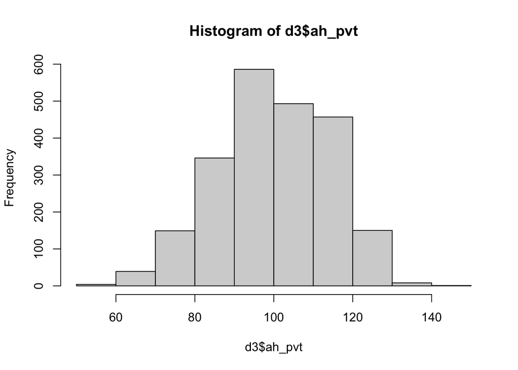

```r
hist(d3$ah_pvt)
```

### b.

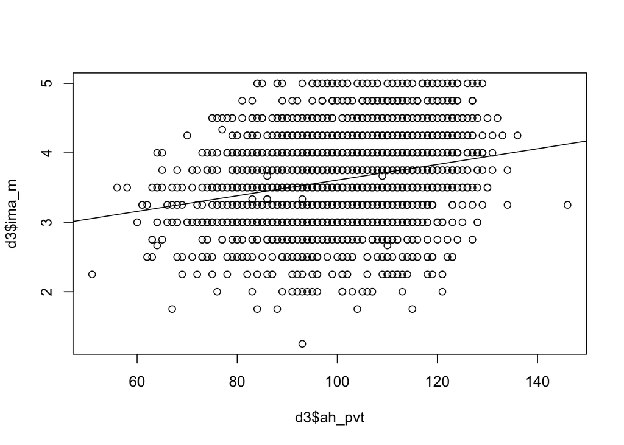

```
## integer(0)
```

```r
plot(d3$ah_pvt, d3$ima_m) + abline(lm(d3$ima_m ~ d3$ah_pvt))
```

### c.

```r
d3$sup_parent_named <- dplyr::recode(d3$sup_parent, "1" = "high", "2" = "low")
```

### d.

```r
table(d3$sup_parent_named, useNA = "always")
```

```
##
## high  low <NA>
## 1170 1041  124
```

### e,

```r
result <- aggregate(agr_m ~ sup_parent_named, data = d3, FUN = function(x) c(mean = mean(x), sd = sd(x)))
```

### f.

```r
cor(d3[, c('ah_pvt', 'sup_parent', 'agr_m', 'ima_m')], use = "pairwise.complete")
```

```
##                 ah_pvt   sup_parent       agr_m       ima_m
## ah_pvt     1.000000000  0.009349272  0.12125424  0.25615236
## sup_parent 0.009349272  1.000000000 -0.06373614 -0.05116586
## agr_m      0.121254242 -0.063736135  1.00000000  0.25355513
## ima_m      0.256152365 -0.051165865  0.25355513  1.00000000
```

## 9.

### a.

```r
d3$predict_0 = 0
d3$errors_0 = d3$ima_m - d3$predict_0
d3$squ_err_0 = d3$errors_0 * d3$errors_0
sse_0 = sum(d3$squ_err_0)
```

#### SSE = 31287.81

### b.

```r
d3$predict_mean = mean(d3$ima_m)
d3$errors_1 = d3$ima_m - d3$predict_mean
d3$squ_err_1 = d3$errors_1 * d3$errors_1
sse_1 = sum(d3$squ_err_1)
```

#### SSE = 901.28

### c.

```r
mod_0 <- lm(ima_m ~ 0, data = d3)
mod_1 <- lm(ima_m ~ 1, data = d3)
anova(mod_0, mod_1)
```

```
## Analysis of Variance Table
##
## Model 1: ima_m ~ 0
## Model 2: ima_m ~ 1
##   Res.Df     RSS Df Sum of Sq     F    Pr(>F)
## 1   2335 31287.8
## 2   2334   901.3  1     30386 78691 < 2.2e-16 ***
## ---
## Signif. codes:  0 '***' 0.001 '**' 0.01 '*' 0.05 '.' 0.1 ' ' 1
```

#### F(1, 2334) = 78691; p < .005.

### d.

#### Since p < .005 (meaning there is a significant relationship between the

#### predictor and outcome variable), it is worth it to estimate another

#### parameter and thus having a more complex model.

### e.

#### This model comparison is also known as an “one sample t-test”.

## 10.

### a.

```r
d3$ah_pvt_c <- d3$ah_pvt - mean(d3$ah_pvt, na.rm = TRUE)
model_1 <- lm(ima_m ~ ah_pvt_c, data = d3)
```

### b.

```r
summary(model_1)
```

```
##
## Call:
## lm(formula = ima_m ~ ah_pvt_c, data = d3)
##
## Residuals:
##      Min       1Q   Median       3Q      Max
## -2.27885 -0.39171  0.01629  0.39387  1.57272
##
## Coefficients:
##              Estimate Std. Error t value Pr(>|t|)
## (Intercept) 3.6133751  0.0127019  284.48   <2e-16 ***
## ah_pvt_c    0.0112854  0.0009016   12.52   <2e-16 ***
## ---
## Signif. codes:  0 '***' 0.001 '**' 0.01 '*' 0.05 '.' 0.1 ' ' 1
##
## Residual standard error: 0.6002 on 2231 degrees of freedom
##   (102 observations deleted due to missingness)
## Multiple R-squared:  0.06561,    Adjusted R-squared:  0.0652
## F-statistic: 156.7 on 1 and 2231 DF,  p-value: < 2.2e-16
```

### c.

```r
car::Anova(model_1, type = 3) %>% eta_squared()
```

```
## # Effect Size for ANOVA
##
## Parameter | Eta2 |       95% CI
## -------------------------------
## ah_pvt_c  | 0.07 | [0.05, 1.00]
##
## - One-sided CIs: upper bound fixed at [1.00].
```

#### Eta Squared is 0.07. This value is the proportion of variance in

#### imagination can be explained by cognitive ability.

### d.

```r
car::Anova(model_1, type = 3)
```

```
## Anova Table (Type III tests)
##
## Response: ima_m
##              Sum Sq   Df  F value    Pr(>F)
## (Intercept) 29155.1    1 80926.11 < 2.2e-16 ***
## ah_pvt_c       56.4    1   156.66 < 2.2e-16 ***
## Residuals     803.8 2231
## ---
## Signif. codes:  0 '***' 0.001 '**' 0.01 '*' 0.05 '.' 0.1 ' ' 1
```

### h.

```r
model_2 <- lm(ima_m ~ ah_pvt, data = d3)
summary(model_2)
```

```
##
## Call:
## lm(formula = ima_m ~ ah_pvt, data = d3)
##
## Residuals:
##      Min       1Q   Median       3Q      Max
## -2.27885 -0.39171  0.01629  0.39387  1.57272
##
## Coefficients:
##              Estimate Std. Error t value Pr(>|t|)
## (Intercept) 2.4793090  0.0914913   27.10   <2e-16 ***
## ah_pvt      0.0112854  0.0009016   12.52   <2e-16 ***
## ---
## Signif. codes:  0 '***' 0.001 '**' 0.01 '*' 0.05 '.' 0.1 ' ' 1
##
## Residual standard error: 0.6002 on 2231 degrees of freedom
##   (102 observations deleted due to missingness)
## Multiple R-squared:  0.06561,    Adjusted R-squared:  0.0652
## F-statistic: 156.7 on 1 and 2231 DF,  p-value: < 2.2e-16
```

#### b0 is now 2.48 and b1 stayed the same. Mean-centering a predictor variable

#### shifts the y axis towards the mean, but does not change the slope.

### i.

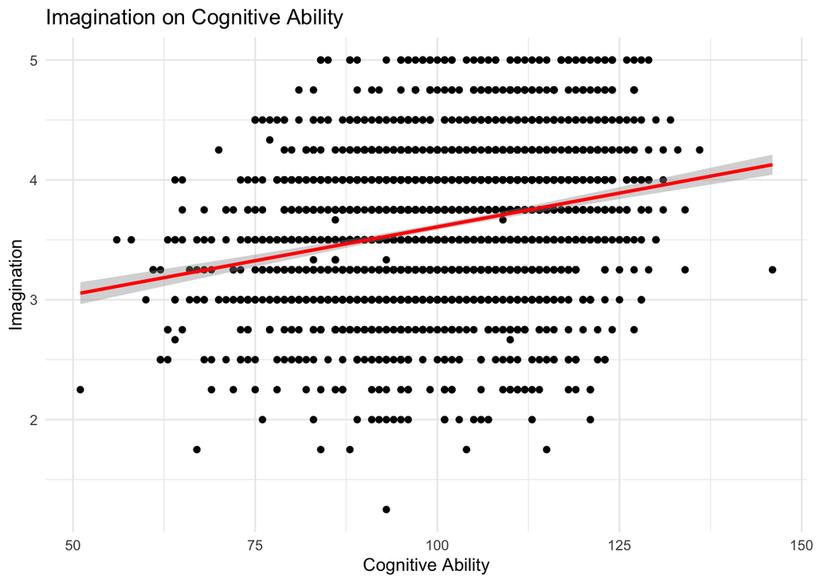

```r
library(ggplot2)
d3$predicted <- predict(model_2, newdata = d3)
ggplot(data = d3, aes(x = ah_pvt, y = ima_m)) +
  geom_point() +  # Scatter plot of raw data points
  geom_smooth(method = "lm", se = TRUE, color = "red") +  # Add regression line with confidence interval
  labs(title = "Imagination on Cognitive Ability",
       x = "Cognitive Ability",
       y = "Imagination") +
  theme_minimal()
```

```r
d3$sup_parent_c <- dplyr::recode(d3$sup_parent, "1" = "-.5", "2" = ".5")
model_3 <- lm(agr_m ~ sup_parent_c, data = d3)
```

### b.

```r
summary(model_3)
```

```
##
## Call:
## lm(formula = agr_m ~ sup_parent_c, data = d3)
##
## Residuals:
##     Min      1Q  Median      3Q     Max
## -2.8323 -0.3323  0.1677  0.4177  1.2449
##
## Coefficients:
##                Estimate Std. Error t value Pr(>|t|)
## (Intercept)     3.83226    0.01763 217.322  < 2e-16 ***
## sup_parent_c.5 -0.07714    0.02570  -3.002  0.00271 **
## ---
## Signif. codes:  0 '***' 0.001 '**' 0.01 '*' 0.05 '.' 0.1 ' ' 1
##
## Residual standard error: 0.6032 on 2209 degrees of freedom
##   (124 observations deleted due to missingness)
## Multiple R-squared:  0.004062,   Adjusted R-squared:  0.003611
## F-statistic:  9.01 on 1 and 2209 DF,  p-value: 0.002715
```

#### F(1, 2209) = 9.01; p = .003

### c.

```r
car::Anova(model_3, type = 3) %>% eta_squared
```

```
## # Effect Size for ANOVA
##
## Parameter    |     Eta2 |       95% CI
## --------------------------------------
## sup_parent_c | 4.06e-03 | [0.00, 1.00]
##
## - One-sided CIs: upper bound fixed at [1.00].
```

#### Eta Squared is 4.06e-03. This value is the proportion of variance in

#### agreeableness can be explained by supportive parenting.

### d.

```r
car::Anova(model_3, type = 3) %>% eta_squared
```

```
## # Effect Size for ANOVA
##
## Parameter    |     Eta2 |       95% CI
## --------------------------------------
## sup_parent_c | 4.06e-03 | [0.00, 1.00]
##
## - One-sided CIs: upper bound fixed at [1.00].
```

### f.

### g.

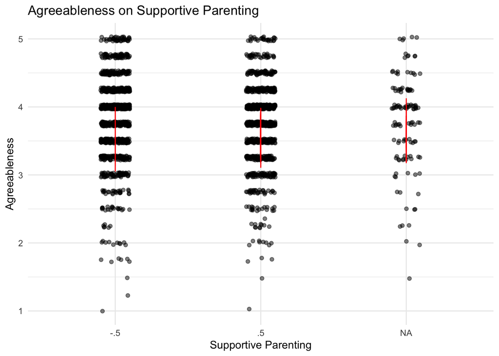

```r
d3$predicted_2 <- predict(model_2, newdata = d3)
ggplot(data = d3, aes(x = sup_parent_c, y = agr_m)) +
  geom_point(position = position_jitter(width = 0.1), alpha = 0.5) +
  geom_line(data = d3, aes(x = sup_parent_c, y = predicted_2), color = "red") +
  labs(title = "Agreeableness on Supportive Parenting",
       x = "Supportive Parenting",
       y = "Agreeableness") +
  theme_minimal()
```

### h.

```r
d3$sup_parent_c2 <- dplyr::recode(d3$sup_parent_c, "-.5" = "-1", ".5" = "1")
model_4 <- lm(agr_m ~ sup_parent_c2, data = d3)
summary(model_4)
```

```
##
## Call:
## lm(formula = agr_m ~ sup_parent_c2, data = d3)
##
## Residuals:
##     Min      1Q  Median      3Q     Max
## -2.8323 -0.3323  0.1677  0.4177  1.2449
##
## Coefficients:
##                Estimate Std. Error t value Pr(>|t|)
## (Intercept)     3.83226    0.01763 217.322  < 2e-16 ***
## sup_parent_c21 -0.07714    0.02570  -3.002  0.00271 **
## ---
## Signif. codes:  0 '***' 0.001 '**' 0.01 '*' 0.05 '.' 0.1 ' ' 1
##
## Residual standard error: 0.6032 on 2209 degrees of freedom
##   (124 observations deleted due to missingness)
## Multiple R-squared:  0.004062,   Adjusted R-squared:  0.003611
## F-statistic:  9.01 on 1 and 2209 DF,  p-value: 0.002715
```

#### Neither b0 or b1 changed. Mean centering the predictor variable has no

#### effect on the slope. Since the predictor was already centered around 0,

#### changing the range (still centered around 0) would not affect the y-axis.

## 12.

### a.

#### parenting. As hypothesized, the effect of supportive parenting was

#### statistically significant, F(1, 2209) = 9.01, p = .003, np^2 = 4.06e-03.

## 13.

### a.

```r
d_married <- d3[d3$parent_div == "Married", ]
d_divorced <- d3[d3$parent_div == "Divorced", ]
model_4 <- lm(agr_m ~ sup_parent_c, data = d_married)
summary(model_4)
```

```
##
## Call:
## lm(formula = agr_m ~ sup_parent_c, data = d_married)
##
## Residuals:
##      Min       1Q   Median       3Q      Max
## -2.74919 -0.33430  0.00081  0.41570  1.25081
##
## Coefficients:
##                Estimate Std. Error t value Pr(>|t|)
## (Intercept)     3.83430    0.02273 168.684   <2e-16 ***
## sup_parent_c.5 -0.08511    0.03310  -2.572   0.0102 *
## ---
## Signif. codes:  0 '***' 0.001 '**' 0.01 '*' 0.05 '.' 0.1 ' ' 1
##
## Residual standard error: 0.5975 on 1306 degrees of freedom
##   (186 observations deleted due to missingness)
## Multiple R-squared:  0.005038,   Adjusted R-squared:  0.004276
## F-statistic: 6.613 on 1 and 1306 DF,  p-value: 0.01023
```

```r
model_5 <- lm(agr_m ~ sup_parent_c, data = d_divorced)
summary(model_5)
```

```
##
## Call:
## lm(formula = agr_m ~ sup_parent_c, data = d_divorced)
##
## Residuals:
##     Min      1Q  Median      3Q     Max
## -2.8394 -0.3394  0.1605  0.4106  1.2444
##
## Coefficients:
##                Estimate Std. Error t value Pr(>|t|)
## (Intercept)     3.83945    0.02983 128.732   <2e-16 ***
## sup_parent_c.5 -0.08387    0.04354  -1.926   0.0544 .
## ---
## Signif. codes:  0 '***' 0.001 '**' 0.01 '*' 0.05 '.' 0.1 ' ' 1
##
## Residual standard error: 0.6127 on 793 degrees of freedom
##   (159 observations deleted due to missingness)
## Multiple R-squared:  0.004657,   Adjusted R-squared:  0.003402
## F-statistic:  3.71 on 1 and 793 DF,  p-value: 0.05444
```

#### The relationship between variables is statistically significant for

#### married parents but not statistically significant for divorced parents.

## 14.

### This assignment took me 10 hours.